# AMF

C. Nell

20180817

### Questions:

#### Q1: Propagule determination: Do AM fungal communities resemble the donor site, irregardless of where soil was delivered?

#### Q2: Environmental filtering: Do AM fungal communities resemble the recipient sites, and are more dissimilar to the donor sites

#### Q3: Propagule pressure: Do AM fungal communities resemble the donor site more in thicker topsoil layer treatments than they do in the control or dusted sites?

Load Required Packages

```r
library(tidyverse)
library(dplyr)
library(reshape2)
library(ggplot2)
library(data.table)
library(stringr)

date <- format(Sys.time(), "%Y%b%d")
date
```

```
## [1] "2018Aug17"
```

** the following is adapted from 2017-07-07_Chapter_2_SSU_IntialClean **

Import data files

```r
# read in OTU table
ssu <- fread("CSS_table_sorted.txt")
str(ssu)
```

```
## Classes 'data.table' and 'data.frame':   386 obs. of  63 variables:
##  $ #OTU ID : chr  "denovo538" "denovo1813859" "denovo1031897" "denovo34" ...
##  $ MM933M  : num  5.29 4.33 7.32 0 0 ...
##  $ MM936M  : num  6.27 11.24 3.4 0 0 ...
##  $ MM941M  : num  4.4 2.95 0 0 0 ...
##  $ MM943M  : num  5.31 4.04 0 0 0 ...
##  $ MM9362CU: num  3.13 3.13 8.77 0 1.56 ...
##  $ MMS700  : num  2.5 6.82 7.82 0 2.5 ...
##  $ MMS701  : num  1.87 2.66 8.27 2.66 0 ...
##  $ MMS702  : num  0 2.79 8.24 2.79 0 ...
##  $ MMS703  : num  0 2.58 7.18 3.45 0 ...
##  $ MMS704  : num  2.75 0 7.43 9.75 0 ...
##  $ MMS705  : num  3.28 0 6.99 0 4.76 ...
##  $ MMS706  : num  1.83 2.61 8.32 0 0 ...
##  $ MMS707  : num  3.03 7.49 7.43 12.04 0 ...
```

[output cut: 50 more lines]

```r
## mapping data
metassu <- fread("map_SSU_Salvage_qiimeformat.txt", header = TRUE)
metassu$Year <- as.character(metassu$Year)
metassu$Rep <- as.factor(metassu$Rep)
str(metassu)
```

```
## Classes 'data.table' and 'data.frame':   62 obs. of  12 variables:
##  $ #SampleID           : int  1 2 3 4 5 6 7 8 9 10 ...
##  $ BarcodeSequence     : chr  "GCAACCTTTGGGTGAT" "GCAACCTTTACTGTGC" "GCAACCTTAGAGTGTG" "GCAACCTTTCGATTGG" ...
##  $ LinkerPrimerSequence: logi  NA NA NA NA NA NA ...
##  $ Location            : chr  "A1" "B1" "C1" "D1" ...
##  $ Project             : chr  "MM-Salvage" "MM-Salvage" "MM-Salvage" "MM-Salvage" ...
##  $ Year                : chr  "2015" "2015" "2015" "2015" ...
##  $ Site                : chr  "WL" "WL" "WL" "WL" ...
##  $ Treat               : chr  "O" "O" "O" "O" ...
##  $ Rep                 : Factor w/ 6 levels "1","2","3","4",..: 1 2 3 4 5 1 1 2 3 1 ...
##  $ TSDel               : chr  NA NA NA NA ...
##  $ Description         : chr  "RecipientPre" "RecipientPre" "RecipientPre" "RecipientPre" ...
##  $ SampleID2           : chr  "MM941M" "MM943M" "MM936M" "MM9362CU" ...
##  - attr(*, ".internal.selfref")=<externalptr>
```

Clean SSU headers

```r
colnames(ssu)
```

```
##  [1] "#OTU ID"  "MM933M"   "MM936M"   "MM941M"   "MM943M"   "MM9362CU"
##  [7] "MMS700"   "MMS701"   "MMS702"   "MMS703"   "MMS704"   "MMS705"
## [13] "MMS706"   "MMS707"   "MMS708"   "MMS709"   "MMS710"   "MMS711"
## [19] "MMS712"   "MMS713"   "MMS714"   "MMS715"   "MMS716"   "MMS717"
## [25] "MMS890"   "MMS891"   "MMS900"   "MMS901"   "MMS902"   "MMS903"
## [31] "MMS904"   "MMS905"   "MMS906"   "MMS907"   "MMS908"   "MMS909"
## [37] "MMS910"   "MMS911"   "MMS912"   "MMS913"   "MMS914"   "MMS915"
## [43] "MMS916"   "MMS917"   "MMS918"   "MMS919"   "MMS920"   "MMS921"
## [49] "MMS922"   "MMS923"   "MMS924"   "MMS925"   "MMS928"   "MMS929"
## [55] "MMS930"   "MMS931"   "MMS932"   "MMS938"   "MMS939"   "MMS942"
## [61] "MMS943"   "MMS944"   "taxonomy"
```

```r
head(ssu$taxonomy)
```

```
## [1] "k__Fungi; p__Glomeromycota; c__Glomeromycetes; o__Glomerales; f__Glomeraceae; g__Glomus; s__NES27"
## [2] "k__Fungi; p__Glomeromycota; c__Glomeromycetes; o__Glomerales; f__Glomeraceae; g__Glomus; s__MH3_B"
## [3] "No blast hit"
## [4] "k__Fungi; p__Glomeromycota; c__Glomeromycetes; o__Glomerales; f__Glomeraceae; g__Glomus; s__NES27"
## [5] "k__Fungi; p__Glomeromycota; c__Glomeromycetes; o__Glomerales; f__Glomeraceae; g__Glomus; s__sp"
## [6] "k__Fungi; p__Glomeromycota; c__Glomeromycetes; o__Diversisporales; f__Acaulosporaceae; g__Acaulospora; s__Acau16"
```

```r
# rename columns
names(ssu)[1] <- "ssuotu"  #rename first column
names(ssu)[names(ssu) == "taxonomy"] <- "ssutaxonomy"  # rename column that is currently called taxonomy

# split taxonomy column
`?`(str_match)
ssu$ssukingdom <- str_match(ssu$ssutaxonomy, "k__(.*?);")[, 2]
ssu$ssuphylum <- str_match(ssu$ssutaxonomy, "p__(.*?);")[, 2]
ssu$ssuclass <- str_match(ssu$ssutaxonomy, "c__(.*?);")[, 2]
ssu$ssuorder <- str_match(ssu$ssutaxonomy, "o__(.*?);")[, 2]
ssu$ssufamily <- str_match(ssu$ssutaxonomy, "f__(.*?);")[, 2]
ssu$ssugenus <- str_match(ssu$ssutaxonomy, "g__(.*?);")[, 2]
ssu$ssuspecies <- str_match(ssu$ssutaxonomy, "s__(.*?)")[, 2]

colnames(ssu)
```

```
##  [1] "ssuotu"      "MM933M"      "MM936M"      "MM941M"      "MM943M"
##  [6] "MM9362CU"    "MMS700"      "MMS701"      "MMS702"      "MMS703"
## [11] "MMS704"      "MMS705"      "MMS706"      "MMS707"      "MMS708"
## [16] "MMS709"      "MMS710"      "MMS711"      "MMS712"      "MMS713"
## [21] "MMS714"      "MMS715"      "MMS716"      "MMS717"      "MMS890"
## [26] "MMS891"      "MMS900"      "MMS901"      "MMS902"      "MMS903"
## [31] "MMS904"      "MMS905"      "MMS906"      "MMS907"      "MMS908"
## [36] "MMS909"      "MMS910"      "MMS911"      "MMS912"      "MMS913"
## [41] "MMS914"      "MMS915"      "MMS916"      "MMS917"      "MMS918"
## [46] "MMS919"      "MMS920"      "MMS921"      "MMS922"      "MMS923"
## [51] "MMS924"      "MMS925"      "MMS928"      "MMS929"      "MMS930"
## [56] "MMS931"      "MMS932"      "MMS938"      "MMS939"      "MMS942"
## [61] "MMS943"      "MMS944"      "ssutaxonomy" "ssukingdom"  "ssuphylum"
## [66] "ssuclass"    "ssuorder"    "ssufamily"   "ssugenus"    "ssuspecies"
```

```r
ssu.save <- ssu

# remove Geosiphonaceae
unique(ssu$ssufamily)
```

```
## [1] "Glomeraceae"          NA                     "Acaulosporaceae"
## [4] "Paraglomeraceae"      "Archaeosporaceae"     "Ambisporaceae"
## [7] "Claroideoglomeraceae" "Diversisporaceae"     "Geosiphonaceae"
```

```r
drop.family <- c("Geosiphonaceae")
ssu <- ssu[-which(ssu$ssufamily %in% drop.family), ]

# remove no blast hits
unique(ssu$ssutaxonomy)
```

```
##  [1] "k__Fungi; p__Glomeromycota; c__Glomeromycetes; o__Glomerales; f__Glomeraceae; g__Glomus; s__NES27"
##  [2] "k__Fungi; p__Glomeromycota; c__Glomeromycetes; o__Glomerales; f__Glomeraceae; g__Glomus; s__MH3_B"
##  [3] "No blast hit"
##  [4] "k__Fungi; p__Glomeromycota; c__Glomeromycetes; o__Glomerales; f__Glomeraceae; g__Glomus; s__sp"
##  [5] "k__Fungi; p__Glomeromycota; c__Glomeromycetes; o__Diversisporales; f__Acaulosporaceae; g__Acaulospora; s__Acau16"
##  [6] "k__Fungi; p__Glomeromycota; c__Glomeromycetes; o__Glomerales; f__Glomeraceae; g__Glomus; s__MO_G47"
##  [7] "k__Fungi; p__Glomeromycota; c__Glomeromycetes; o__Paraglomerales; f__Paraglomeraceae; g__Paraglomus; s__laccatum"
##  [8] "k__Fungi; p__Glomeromycota; c__Glomeromycetes; o__Glomerales; f__Glomeraceae; g__Glomus; s__acnaGlo2"
##  [9] "k__Fungi; p__Glomeromycota; c__Glomeromycetes; o__Archaeosporales; f__Archaeosporaceae; g__Archaeospora; s__MO_Ar1"
## [10] "k__Fungi; p__Glomeromycota; c__Glomeromycetes; o__Archaeosporales; f__Archaeosporaceae; g__Archaeospora; s__sp"
## [11] "k__Fungi; p__Glomeromycota; c__Glomeromycetes; o__Archaeosporales; f__Ambisporaceae; g__Ambispora; s__leptoticha"
## [12] "k__Fungi; p__Glomeromycota; c__Glomeromycetes; o__Glomerales; f__Glomeraceae; g__Glomus; s__Whitfield_type_7"
## [13] "k__Fungi; p__Glomeromycota; c__Glomeromycetes; o__Glomerales; f__Claroideoglomeraceae; g__Claroideoglomus; s__Torrecillas12b_Glo_G5"
## [14] "k__Fungi; p__Glomeromycota; c__Glomeromycetes; o__Glomerales; f__Glomeraceae; g__Glomus; s__Sanchez_Castro12b_GLO12"
## [15] "k__Fungi; p__Glomeromycota; c__Glomeromycetes; o__Glomerales; f__Glomeraceae; g__Glomus; s__Winther07_D"
```

[output cut: 49 more lines]

```r
drop <- c("No blast hit")
ssu <- ssu[-which(ssu$ssutaxonomy %in% drop), ]

## alternatively, can use filtering to drop these and avoid rewriting things
ssu <- ssu.save %>% filter(ssufamily != "Geosiphonaceae" & ssutaxonomy != "No blast hit")
```

Add in functional groups

```r
# this does the same as above but avoids hard coding names, more generalized
ssu.fg <- ssu %>% mutate(Functional.Group = case_when(ssufamily %in% c("Glomeraceae",
    "Claroideoglomeraceae", "Paraglomeraceae") ~ "Rhizophilic", ssufamily %in%
    c("Gigasporaceae", "Diversisporaceae") ~ "Edaphophilic", ssufamily %in%
    c("Ambisporaceae", "Archaeosporaceae", "Acaulosporaceae") ~ "Ancestral"))
```

Take data from wide to long and renaming variables

```r
ssul <- melt(ssu.fg, variable.name = "ID", value.name = "ssureads")
str(ssul)
```

```
## 'data.frame':    17568 obs. of  12 variables:
##  $ ssuotu          : chr  "denovo538" "denovo1813859" "denovo34" "denovo11952" ...
##  $ ssutaxonomy     : chr  "k__Fungi; p__Glomeromycota; c__Glomeromycetes; o__Glomerales; f__Glomeraceae; g__Glomus; s__NES27" "k__Fungi; p__Glomeromycota; c__Glomeromycetes; o__Glomerales; f__Glomeraceae; g__Glomus; s__MH3_B" "k__Fungi; p__Glomeromycota; c__Glomeromycetes; o__Glomerales; f__Glome…
##  $ ssukingdom      : chr  "Fungi" "Fungi" "Fungi" "Fungi" ...
##  $ ssuphylum       : chr  "Glomeromycota" "Glomeromycota" "Glomeromycota" "Glomeromycota" ...
##  $ ssuclass        : chr  "Glomeromycetes" "Glomeromycetes" "Glomeromycetes" "Glomeromycetes" ...
##  $ ssuorder        : chr  "Glomerales" "Glomerales" "Glomerales" "Glomerales" ...
##  $ ssufamily       : chr  "Glomeraceae" "Glomeraceae" "Glomeraceae" "Glomeraceae" ...
##  $ ssugenus        : chr  "Glomus" "Glomus" "Glomus" "Glomus" ...
##  $ ssuspecies      : chr  "" "" "" "" ...
##  $ Functional.Group: chr  "Rhizophilic" "Rhizophilic" "Rhizophilic" "Rhizophilic" ...
##  $ ID              : Factor w/ 61 levels "MM933M","MM936M",..: 1 1 1 1 1 1 1 1 1 1 ...
##  $ ssureads        : num  5.29 4.33 0 0 3.78 ...
```

Functional group OTU richnesses and read abundance for each functional group

Below is in format for graphing

```r
ssuguildREADRICH <- data.frame(ssul %>% group_by(ID, Functional.Group) %>% summarise(OTU_Richness_Sample = length(unique(ssuotu[ssureads >
    0])), Read_Abundance_Sample = sum(ssureads)))
```

Make SSU data frame with family level OTU richness and Read abundance for each family

```r
ssufamily <- data.frame(ssul %>% group_by(ID, ssufamily) %>% summarise(Family_OTU_Richness = length(unique(ssuotu[ssureads >
    0])), Family_Read_Abundance = sum(ssureads)))
```

Add metadata into ssu family

```r
colnames(metassu)  # need to edit for appropriate headers
```

```
##  [1] "#SampleID"            "BarcodeSequence"      "LinkerPrimerSequence"
##  [4] "Location"             "Project"              "Year"
##  [7] "Site"                 "Treat"                "Rep"
## [10] "TSDel"                "Description"          "SampleID2"
```

```r
names(metassu)[names(metassu) == "SampleID2"] <- "ID"

ssufamily <- ssufamily %>% left_join(metassu, by = "ID")
str(ssufamily)
```

```
## 'data.frame':    427 obs. of  15 variables:
##  $ ID                   : chr  "MM933M" "MM933M" "MM933M" "MM933M" ...
##  $ ssufamily            : chr  "Acaulosporaceae" "Ambisporaceae" "Archaeosporaceae" "Claroideoglomeraceae" ...
##  $ Family_OTU_Richness  : int  4 5 17 15 2 65 22 3 5 12 ...
##  $ Family_Read_Abundance: num  12.4 23.9 157.6 99.6 23.2 ...
##  $ #SampleID            : int  5 5 5 5 5 5 5 3 3 3 ...
##  $ BarcodeSequence      : chr  "ATCCCGTATCGATTGG" "ATCCCGTATCGATTGG" "ATCCCGTATCGATTGG" "ATCCCGTATCGATTGG" ...
##  $ LinkerPrimerSequence : logi  NA NA NA NA NA NA ...
##  $ Location             : chr  "E1" "E1" "E1" "E1" ...
##  $ Project              : chr  "MM-Salvage" "MM-Salvage" "MM-Salvage" "MM-Salvage" ...
##  $ Year                 : chr  "2015" "2015" "2015" "2015" ...
##  $ Site                 : chr  "WL" "WL" "WL" "WL" ...
##  $ Treat                : chr  "O" "O" "O" "O" ...
##  $ Rep                  : Factor w/ 6 levels "1","2","3","4",..: 5 5 5 5 5 5 5 3 3 3 ...
##  $ TSDel                : chr  NA NA NA NA ...
##  $ Description          : chr  "RecipientPre" "RecipientPre" "RecipientPre" "RecipientPre" ...
```

```r
ssuguildREADRICH <- ssuguildREADRICH %>% left_join(metassu, by = "ID")
str(ssuguildREADRICH)
```

```
## 'data.frame':    183 obs. of  15 variables:
##  $ ID                   : chr  "MM933M" "MM933M" "MM933M" "MM936M" ...
##  $ Functional.Group     : chr  "Ancestral" "Edaphophilic" "Rhizophilic" "Ancestral" ...
##  $ OTU_Richness_Sample  : int  26 2 102 20 1 84 19 1 101 20 ...
##  $ Read_Abundance_Sample: num  194 23.2 616.6 103.9 12.2 ...
##  $ #SampleID            : int  5 5 5 3 3 3 1 1 1 2 ...
##  $ BarcodeSequence      : chr  "ATCCCGTATCGATTGG" "ATCCCGTATCGATTGG" "ATCCCGTATCGATTGG" "GCAACCTTAGAGTGTG" ...
##  $ LinkerPrimerSequence : logi  NA NA NA NA NA NA ...
##  $ Location             : chr  "E1" "E1" "E1" "C1" ...
##  $ Project              : chr  "MM-Salvage" "MM-Salvage" "MM-Salvage" "MM-Salvage" ...
##  $ Year                 : chr  "2015" "2015" "2015" "2015" ...
##  $ Site                 : chr  "WL" "WL" "WL" "WL" ...
##  $ Treat                : chr  "O" "O" "O" "O" ...
##  $ Rep                  : Factor w/ 6 levels "1","2","3","4",..: 5 5 5 3 3 3 1 1 1 2 ...
##  $ TSDel                : chr  NA NA NA NA ...
##  $ Description          : chr  "RecipientPre" "RecipientPre" "RecipientPre" "RecipientPre" ...
```

```r
filename <- paste0(date, "_ssu_funcguild_read_rich.csv")
write.csv(ssuguildREADRICH, file = filename, row.names = FALSE)
```

Adds meta data to data for box plot

```r
### For ssufamily, moves ID to single line and family to the length
LssufamilyOTURICH <- dcast(ssufamily, ID ~ ssufamily, value.var = "Family_OTU_Richness",
    fun.aggregate = sum)
LssufamilyOTUREAD <- dcast(ssufamily, ID ~ ssufamily, value.var = "Family_Read_Abundance",
    fun.aggregate = sum)

head(LssufamilyOTUREAD)
```

```
##         ID Acaulosporaceae Ambisporaceae Archaeosporaceae
## 1   MM933M         12.4250       23.9417         157.5890
## 2 MM9362CU         15.4041       33.2473          63.2683
## 3   MM936M         10.1868       25.9602          67.7783
## 4   MM941M         33.0782       14.6280          47.8637
## 5   MM943M         44.8828       23.4654          92.1497
## 6   MMS700         22.8050       20.1172          90.3423
##   Claroideoglomeraceae Diversisporaceae Glomeraceae Paraglomeraceae
## 1              99.6242          23.1980    387.3753        129.6337
## 2             118.7108          18.3924    464.2526        172.7572
## 3              91.5404          12.2380    406.1616         81.1362
## 4              93.6373          13.9450    503.8588         81.3654
## 5              74.7298          22.9824    317.0982        103.0184
## 6             106.1814          18.6176    429.0388        118.3515
```

Functional group read and richness together

```r
ssuguildREADRICHlong <- data.frame(ssul %>% group_by(ID) %>% summarise(OTU_Richness_Sample = length(unique(ssuotu[ssureads >
    0])), Ancestral_Richness = length(unique(ssuotu[ssureads > 0 & Functional.Group ==
    "Ancestral"])), Edaphophilic_Richness = length(unique(ssuotu[ssureads >
    0 & Functional.Group == "Edaphophilic"])), Rhizophilic_Richness = length(unique(ssuotu[ssureads >
    0 & Functional.Group == "Rhizophilic"])), Ancestral_Read_Abundance = sum(ssureads[Functional.Group ==
    "Ancestral"]), Edaphophilic_Read_Abundance = sum(ssureads[Functional.Group ==
    "Edaphophilic"]), Rhizophilic_Read_Abundance = sum(ssureads[Functional.Group ==
    "Rhizophilic"]), Read_Abundance_Sample = sum(ssureads)))
View(ssuguildREADRICHlong)
ssuguildREADRICHlong <- merge(ssuguildREADRICHlong, metassu, by = "ID")

filename <- paste0(date, "_ssu_funcguild_read_rich.csv")
write.csv(ssuguildREADRICHlong, file = filename, row.names = FALSE)

str(ssuguildREADRICHlong)
```

```
## 'data.frame':    61 obs. of  20 variables:
##  $ ID                         : Factor w/ 61 levels "MM933M","MM936M",..: 1 5 2 3 4 6 7 8 9 10 ...
##  $ OTU_Richness_Sample        : int  130 167 105 121 99 151 158 161 138 148 ...
##  $ Ancestral_Richness         : int  26 28 20 19 20 23 22 24 19 23 ...
##  $ Edaphophilic_Richness      : int  2 3 1 1 3 3 2 4 2 1 ...
##  $ Rhizophilic_Richness       : int  102 136 84 101 76 125 134 133 117 124 ...
##  $ Ancestral_Read_Abundance   : num  194 111.9 103.9 95.6 160.5 ...
##  $ Edaphophilic_Read_Abundance: num  23.2 18.4 12.2 13.9 23 ...
##  $ Rhizophilic_Read_Abundance : num  617 756 579 679 495 ...
##  $ Read_Abundance_Sample      : num  834 886 695 788 678 ...
##  $ #SampleID                  : int  5 4 3 1 2 47 48 49 50 51 ...
##  $ BarcodeSequence            : chr  "ATCCCGTATCGATTGG" "GCAACCTTTCGATTGG" "GCAACCTTAGAGTGTG" "GCAACCTTTGGGTGAT" ...
##  $ LinkerPrimerSequence       : logi  NA NA NA NA NA NA ...
##  $ Location                   : chr  "E1" "D1" "C1" "A1" ...
##  $ Project                    : chr  "MM-Salvage" "MM-Salvage" "MM-Salvage" "MM-Salvage" ...
##  $ Year                       : chr  "2015" "2015" "2015" "2015" ...
##  $ Site                       : chr  "WL" "WL" "WL" "WL" ...
##  $ Treat                      : chr  "O" "O" "O" "O" ...
##  $ Rep                        : Factor w/ 6 levels "1","2","3","4",..: 5 4 3 1 2 1 2 3 1 2 ...
##  $ TSDel                      : chr  NA NA NA NA ...
##  $ Description                : chr  "RecipientPre" "RecipientPre" "RecipientPre" "RecipientPre" ...
```

Functional group read and richness separate

```r
ssuguildREAD <- ssul %>% group_by(ID) %>% summarise(Ancestral_Read_Abundance = sum(ssureads[Functional.Group ==
    "Ancestral"]), Edaphophilic_Read_Abundance = sum(ssureads[Functional.Group ==
    "Edaphophilic"]), Rhizophilic_Read_Abundance = sum(ssureads[Functional.Group ==
    "Rhizophilic"]))


ssuguildRICH <- ssul %>% group_by(ID) %>% summarise(OTU_Richness_Sample = length(unique(ssuotu[ssureads >
    0])), Ancestral_Richness = length(unique(ssuotu[ssureads > 0 & Functional.Group ==
    "Ancestral"])), Edaphophilic_Richness = length(unique(ssuotu[ssureads >
    0 & Functional.Group == "Edaphophilic"])), Rhizophilic_Richness = length(unique(ssuotu[ssureads >
    0 & Functional.Group == "Rhizophilic"])))
head(ssuguildRICH)
```

```
## # A tibble: 6 x 5
##         ID OTU_Richness_Sample Ancestral_Richness Edaphophilic_Richness
##     <fctr>               <int>              <int>                 <int>
## 1   MM933M                 130                 26                     2
## 2   MM936M                 105                 20                     1
## 3   MM941M                 121                 19                     1
## 4   MM943M                  99                 20                     3
## 5 MM9362CU                 167                 28                     3
## 6   MMS700                 151                 23                     3
## # ... with 1 more variables: Rhizophilic_Richness <int>
```

Add metadata to above

```r
ssuguildRICH <- merge(ssuguildRICH, metassu, by = "ID")
ssuguildREAD <- merge(ssuguildREAD, metassu, by = "ID")
str(ssuguildRICH)
```

```
## 'data.frame':    61 obs. of  16 variables:
##  $ ID                   : Factor w/ 61 levels "MM933M","MM936M",..: 1 5 2 3 4 6 7 8 9 10 ...
##  $ OTU_Richness_Sample  : int  130 167 105 121 99 151 158 161 138 148 ...
##  $ Ancestral_Richness   : int  26 28 20 19 20 23 22 24 19 23 ...
##  $ Edaphophilic_Richness: int  2 3 1 1 3 3 2 4 2 1 ...
##  $ Rhizophilic_Richness : int  102 136 84 101 76 125 134 133 117 124 ...
##  $ #SampleID            : int  5 4 3 1 2 47 48 49 50 51 ...
##  $ BarcodeSequence      : chr  "ATCCCGTATCGATTGG" "GCAACCTTTCGATTGG" "GCAACCTTAGAGTGTG" "GCAACCTTTGGGTGAT" ...
##  $ LinkerPrimerSequence : logi  NA NA NA NA NA NA ...
##  $ Location             : chr  "E1" "D1" "C1" "A1" ...
##  $ Project              : chr  "MM-Salvage" "MM-Salvage" "MM-Salvage" "MM-Salvage" ...
##  $ Year                 : chr  "2015" "2015" "2015" "2015" ...
##  $ Site                 : chr  "WL" "WL" "WL" "WL" ...
##  $ Treat                : chr  "O" "O" "O" "O" ...
##  $ Rep                  : Factor w/ 6 levels "1","2","3","4",..: 5 4 3 1 2 1 2 3 1 2 ...
##  $ TSDel                : chr  NA NA NA NA ...
##  $ Description          : chr  "RecipientPre" "RecipientPre" "RecipientPre" "RecipientPre" ...
```

```r
str(ssuguildREAD)
```

```
## 'data.frame':    61 obs. of  15 variables:
##  $ ID                         : Factor w/ 61 levels "MM933M","MM936M",..: 1 5 2 3 4 6 7 8 9 10 ...
##  $ Ancestral_Read_Abundance   : num  194 111.9 103.9 95.6 160.5 ...
##  $ Edaphophilic_Read_Abundance: num  23.2 18.4 12.2 13.9 23 ...
##  $ Rhizophilic_Read_Abundance : num  617 756 579 679 495 ...
##  $ #SampleID                  : int  5 4 3 1 2 47 48 49 50 51 ...
##  $ BarcodeSequence            : chr  "ATCCCGTATCGATTGG" "GCAACCTTTCGATTGG" "GCAACCTTAGAGTGTG" "GCAACCTTTGGGTGAT" ...
##  $ LinkerPrimerSequence       : logi  NA NA NA NA NA NA ...
##  $ Location                   : chr  "E1" "D1" "C1" "A1" ...
##  $ Project                    : chr  "MM-Salvage" "MM-Salvage" "MM-Salvage" "MM-Salvage" ...
##  $ Year                       : chr  "2015" "2015" "2015" "2015" ...
##  $ Site                       : chr  "WL" "WL" "WL" "WL" ...
##  $ Treat                      : chr  "O" "O" "O" "O" ...
##  $ Rep                        : Factor w/ 6 levels "1","2","3","4",..: 5 4 3 1 2 1 2 3 1 2 ...
##  $ TSDel                      : chr  NA NA NA NA ...
##  $ Description                : chr  "RecipientPre" "RecipientPre" "RecipientPre" "RecipientPre" ...
```

```r
y <- ssuguildRICH$Rhizophilic_Richness
str(y)
```

```
##  int [1:61] 102 136 84 101 76 125 134 133 117 124 ...
```

```r
D <- ssuguildRICH$Description
S <- ssuguildRICH$Site

length(S)
```

```
## [1] 61
```

```r
length(D)
```

```
## [1] 61
```

```r
`?`(lm)
# lm(y~D)
SRhizRich <- lm(y ~ S)
str(SRhizRich)
```

[output not shown]

```r
DRhizRich <- lm(y ~ D)
str(DRhizRich)
```

[output not shown]

```r
DSRhizRich <- lm(y ~ S * D)
str(DSRhizRich)
```

[output not shown]

[output cut: 11 more lines]

```
##   ..- attr(*, "terms")=Classes 'terms', 'formula'  language y ~ S * D
##   .. .. ..- attr(*, "variables")= language list(y, S, D)
##   .. .. ..- attr(*, "factors")= int [1:3, 1:3] 0 1 0 0 0 1 0 1 1
##   .. .. .. ..- attr(*, "dimnames")=List of 2
##   .. .. .. .. ..$ : chr [1:3] "y" "S" "D"
##   .. .. .. .. ..$ : chr [1:3] "S" "D" "S:D"
##   .. .. ..- attr(*, "term.labels")= chr [1:3] "S" "D" "S:D"
##   .. .. ..- attr(*, "order")= int [1:3] 1 1 2
##   .. .. ..- attr(*, "intercept")= int 1
##   .. .. ..- attr(*, "response")= int 1
##   .. .. ..- attr(*, ".Environment")=<environment: R_GlobalEnv>
##   .. .. ..- attr(*, "predvars")= language list(y, S, D)
##   .. .. ..- attr(*, "dataClasses")= Named chr [1:3] "numeric" "character" "character"
##   .. .. .. ..- attr(*, "names")= chr [1:3] "y" "S" "D"
##  - attr(*, "class")= chr "lm"
```

```r
summary(DSRhizRich)
```

```
##
## Call:
## lm(formula = y ~ S * D)
##
## Residuals:
##     Min      1Q  Median      3Q     Max
## -42.304  -7.304   2.000   7.000  35.167
##
## Coefficients: (5 not defined because of singularities)
##                    Estimate Std. Error t value Pr(>|t|)
## (Intercept)         125.400      6.942  18.065  < 2e-16 ***
## SHH                   8.600     12.987   0.662  0.51065
## SPS                  -3.400     10.413  -0.327  0.74529
## SWL                 -18.567      9.399  -1.975  0.05335 .
## DRecipientPost       31.167      8.962   3.478  0.00101 **
## DRecipientPre            NA         NA      NA       NA
## SHH:DRecipientPost  -26.862     14.535  -1.848  0.07006 .
## SPS:DRecipientPost  -19.033     12.514  -1.521  0.13411
## SWL:DRecipientPost       NA         NA      NA       NA
## SHH:DRecipientPre        NA         NA      NA       NA
## SPS:DRecipientPre        NA         NA      NA       NA
## SWL:DRecipientPre        NA         NA      NA       NA
## ---
## Signif. codes:  0 '***' 0.001 '**' 0.01 '*' 0.05 '.' 0.1 ' ' 1
##
## Residual standard error: 15.52 on 54 degrees of freedom
## Multiple R-squared:  0.3018, Adjusted R-squared:  0.2242
## F-statistic:  3.89 on 6 and 54 DF,  p-value: 0.002672
```

```r
y <- ssuguildRICH$Rhizophilic_Richness
str(y)
```

```
##  int [1:61] 102 136 84 101 76 125 134 133 117 124 ...
```

```r
D <- ssuguildRICH$Description
S <- ssuguildRICH$Site
length(S)
```

```
## [1] 61
```

```r
length(D)
```

```
## [1] 61
```

```r
`?`(lm)

glm(y ~ D)
```

```
##
## Call:  glm(formula = y ~ D)
##
## Coefficients:
##    (Intercept)  DRecipientPost   DRecipientPre
##        125.400          11.441          -8.983
##
## Degrees of Freedom: 60 Total (i.e. Null);  58 Residual
## Null Deviance:       18630
## Residual Deviance: 14470     AIC: 514.7
```

```r
G_SRhizRich <- glm(y ~ S)
str(G_SRhizRich)
```

[output not shown]

[output cut: 44 more lines]

```
##   .. ..- attr(*, "predvars")= language list(y, S)
##   .. ..- attr(*, "dataClasses")= Named chr [1:2] "numeric" "character"
##   .. .. ..- attr(*, "names")= chr [1:2] "y" "S"
##  $ data             :<environment: R_GlobalEnv>
##  $ offset           : NULL
##  $ control          :List of 3
##   ..$ epsilon: num 1e-08
##   ..$ maxit  : num 25
##   ..$ trace  : logi FALSE
##  $ method           : chr "glm.fit"
##  $ contrasts        :List of 1
##   ..$ S: chr "contr.treatment"
##  $ xlevels          :List of 1
##   ..$ S: chr [1:4] "DS" "HH" "PS" "WL"
##  - attr(*, "class")= chr [1:2] "glm" "lm"
```

```r
G_DRhizRich <- glm(y ~ D)
str(G_DRhizRich)
```

[output not shown]

[output cut: 44 more lines]

```
##   .. ..- attr(*, "predvars")= language list(y, D)
##   .. ..- attr(*, "dataClasses")= Named chr [1:2] "numeric" "character"
##   .. .. ..- attr(*, "names")= chr [1:2] "y" "D"
##  $ data             :<environment: R_GlobalEnv>
##  $ offset           : NULL
##  $ control          :List of 3
##   ..$ epsilon: num 1e-08
##   ..$ maxit  : num 25
##   ..$ trace  : logi FALSE
##  $ method           : chr "glm.fit"
##  $ contrasts        :List of 1
##   ..$ D: chr "contr.treatment"
##  $ xlevels          :List of 1
##   ..$ D: chr [1:3] "Donor" "RecipientPost" "RecipientPre"
##  - attr(*, "class")= chr [1:2] "glm" "lm"
```

```r
summary(G_DRhizRich)
```

```
##
## Call:
## glm(formula = y ~ D)
##
## Deviance Residuals:
##     Min       1Q   Median       3Q      Max
## -40.841   -8.400    3.159   10.159   26.159
##
## Coefficients:
##                Estimate Std. Error t value Pr(>|t|)
## (Intercept)     125.400      7.064  17.751   <2e-16 ***
## DRecipientPost   11.441      7.455   1.535     0.13
## DRecipientPre    -8.983      8.408  -1.068     0.29
## ---
## Signif. codes:  0 '***' 0.001 '**' 0.01 '*' 0.05 '.' 0.1 ' ' 1
##
## (Dispersion parameter for gaussian family taken to be 249.5173)
##
##     Null deviance: 18634  on 60  degrees of freedom
## Residual deviance: 14472  on 58  degrees of freedom
## AIC: 514.73
##
## Number of Fisher Scoring iterations: 2
```

```r
DSRhizRich <- lm(y ~ S * D)
str(DSRhizRich)
```

[output not shown]

[output cut: 11 more lines]

```
##   ..- attr(*, "terms")=Classes 'terms', 'formula'  language y ~ S * D
##   .. .. ..- attr(*, "variables")= language list(y, S, D)
##   .. .. ..- attr(*, "factors")= int [1:3, 1:3] 0 1 0 0 0 1 0 1 1
##   .. .. .. ..- attr(*, "dimnames")=List of 2
##   .. .. .. .. ..$ : chr [1:3] "y" "S" "D"
##   .. .. .. .. ..$ : chr [1:3] "S" "D" "S:D"
##   .. .. ..- attr(*, "term.labels")= chr [1:3] "S" "D" "S:D"
##   .. .. ..- attr(*, "order")= int [1:3] 1 1 2
##   .. .. ..- attr(*, "intercept")= int 1
##   .. .. ..- attr(*, "response")= int 1
##   .. .. ..- attr(*, ".Environment")=<environment: R_GlobalEnv>
##   .. .. ..- attr(*, "predvars")= language list(y, S, D)
##   .. .. ..- attr(*, "dataClasses")= Named chr [1:3] "numeric" "character" "character"
##   .. .. .. ..- attr(*, "names")= chr [1:3] "y" "S" "D"
##  - attr(*, "class")= chr "lm"
```

```r
summary(DSRhizRich)
```

```
##
## Call:
## lm(formula = y ~ S * D)
##
## Residuals:
##     Min      1Q  Median      3Q     Max
## -42.304  -7.304   2.000   7.000  35.167
##
## Coefficients: (5 not defined because of singularities)
##                    Estimate Std. Error t value Pr(>|t|)
## (Intercept)         125.400      6.942  18.065  < 2e-16 ***
## SHH                   8.600     12.987   0.662  0.51065
## SPS                  -3.400     10.413  -0.327  0.74529
## SWL                 -18.567      9.399  -1.975  0.05335 .
## DRecipientPost       31.167      8.962   3.478  0.00101 **
## DRecipientPre            NA         NA      NA       NA
## SHH:DRecipientPost  -26.862     14.535  -1.848  0.07006 .
## SPS:DRecipientPost  -19.033     12.514  -1.521  0.13411
## SWL:DRecipientPost       NA         NA      NA       NA
## SHH:DRecipientPre        NA         NA      NA       NA
## SPS:DRecipientPre        NA         NA      NA       NA
## SWL:DRecipientPre        NA         NA      NA       NA
## ---
## Signif. codes:  0 '***' 0.001 '**' 0.01 '*' 0.05 '.' 0.1 ' ' 1
##
## Residual standard error: 15.52 on 54 degrees of freedom
## Multiple R-squared:  0.3018, Adjusted R-squared:  0.2242
## F-statistic:  3.89 on 6 and 54 DF,  p-value: 0.002672
```

```r
lm(y ~ D * S)
```

```
##
## Call:
## lm(formula = y ~ D * S)
##
## Coefficients:
##        (Intercept)      DRecipientPost       DRecipientPre
##             125.40               12.60              -18.57
##                SHH                 SPS                 SWL
##              27.17               15.17                  NA
## DRecipientPost:SHH   DRecipientPre:SHH  DRecipientPost:SPS
##             -26.86                  NA              -19.03
##  DRecipientPre:SPS  DRecipientPost:SWL   DRecipientPre:SWL
##                 NA                  NA                  NA
```

```r
lm(y ~ D + S)
```

```
##
## Call:
## lm(formula = y ~ D + S)
##
## Coefficients:
##    (Intercept)  DRecipientPost   DRecipientPre             SHH
##        125.400           5.752         -11.719           8.205
##            SPS             SWL
##          4.105              NA
```

```r
`?`(glm)
glm(y ~ D)
```

```
##
## Call:  glm(formula = y ~ D)
##
## Coefficients:
##    (Intercept)  DRecipientPost   DRecipientPre
##        125.400          11.441          -8.983
##
## Degrees of Freedom: 60 Total (i.e. Null);  58 Residual
## Null Deviance:       18630
## Residual Deviance: 14470     AIC: 514.7
```

```r
# Description+Site
```

**Does not apply below**

Separating data by root and soil

Pull out roots and soil for Family DFs

Plotting  
**start ‘2017_16_07_SSU_Boxplots.R’**

```r
# richness
plot.df <- ssuguildREADRICH
str(plot.df)
```

```
## 'data.frame':    183 obs. of  15 variables:
##  $ ID                   : chr  "MM933M" "MM933M" "MM933M" "MM936M" ...
##  $ Functional.Group     : chr  "Ancestral" "Edaphophilic" "Rhizophilic" "Ancestral" ...
##  $ OTU_Richness_Sample  : int  26 2 102 20 1 84 19 1 101 20 ...
##  $ Read_Abundance_Sample: num  194 23.2 616.6 103.9 12.2 ...
##  $ #SampleID            : int  5 5 5 3 3 3 1 1 1 2 ...
##  $ BarcodeSequence      : chr  "ATCCCGTATCGATTGG" "ATCCCGTATCGATTGG" "ATCCCGTATCGATTGG" "GCAACCTTAGAGTGTG" ...
##  $ LinkerPrimerSequence : logi  NA NA NA NA NA NA ...
##  $ Location             : chr  "E1" "E1" "E1" "C1" ...
##  $ Project              : chr  "MM-Salvage" "MM-Salvage" "MM-Salvage" "MM-Salvage" ...
##  $ Year                 : chr  "2015" "2015" "2015" "2015" ...
##  $ Site                 : chr  "WL" "WL" "WL" "WL" ...
##  $ Treat                : chr  "O" "O" "O" "O" ...
##  $ Rep                  : Factor w/ 6 levels "1","2","3","4",..: 5 5 5 3 3 3 1 1 1 2 ...
##  $ TSDel                : chr  NA NA NA NA ...
##  $ Description          : chr  "RecipientPre" "RecipientPre" "RecipientPre" "RecipientPre" ...
```

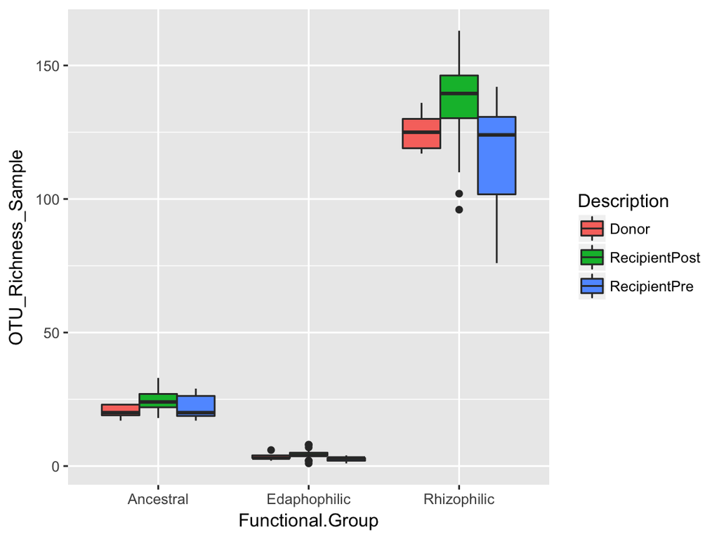

```r
richbox <- ggplot(plot.df, aes(x = Functional.Group, y = OTU_Richness_Sample)) +
    geom_boxplot(aes(fill = Description))
richbox
```

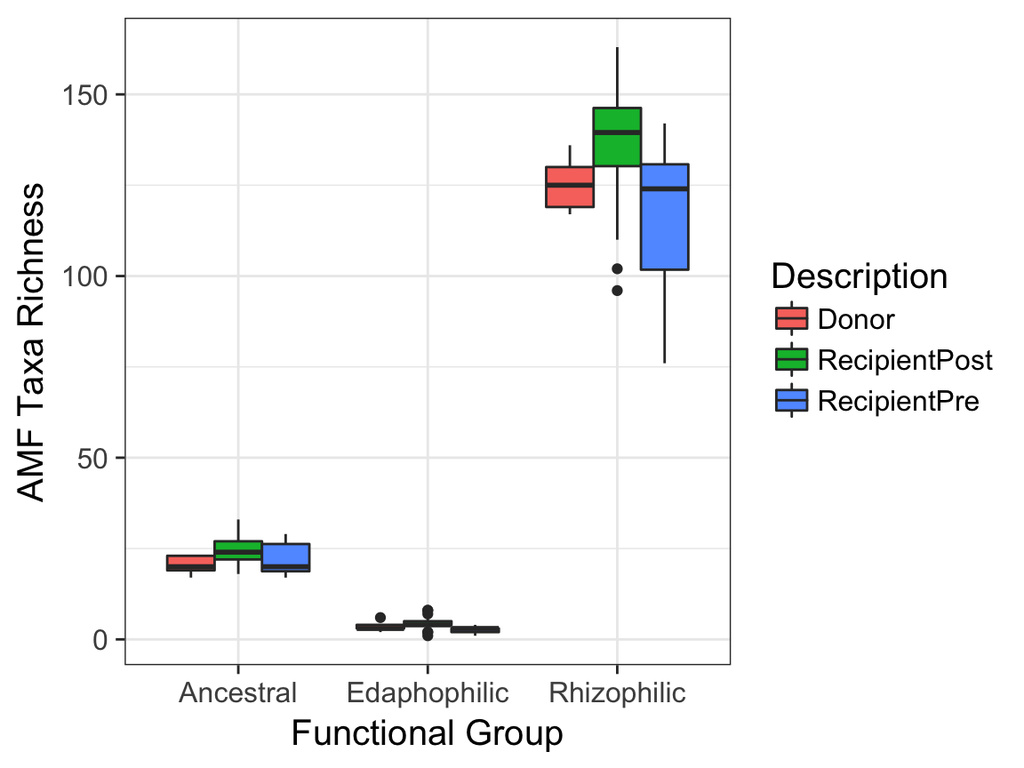

```r
richbox <- richbox + theme_bw(base_size = 15) + xlab("Functional Group") + ylab("AMF Taxa Richness")
richbox
```

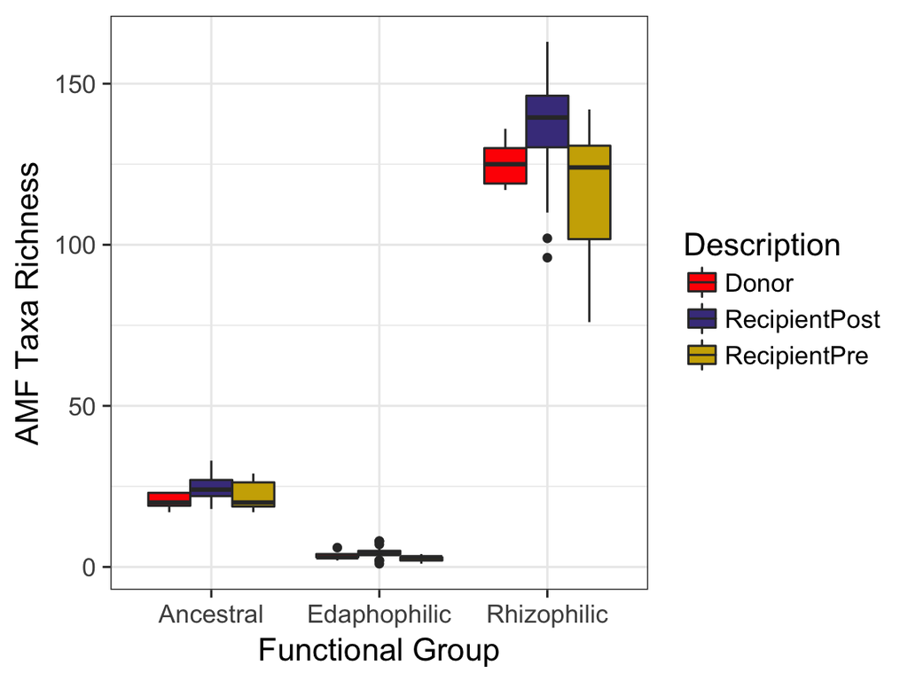

```r
richbox <- richbox + scale_fill_manual(values = c("red", "darkslateblue", "gold3"))
richbox
```

```r
## reads
plot.read <- ssuguildREAD
str(plot.read)

# reachbox <- ggplot(plot.read, aes(x = Functional.Group , y =
# OTU_Richness_Sample)) + geom_boxplot(aes(fill = Description))
reachbox

reachbox <- reachbox + theme_bw(base_size = 15) + xlab("Functional Group") +
    ylab("AMF Taxa Reads")
reachbox

reachbox <- reachbox + scale_fill_manual(values = c("red", "darkslateblue",
    "gold3"))
reachbox
```

[output not shown]